# Simplification des sols de la Limagne selon un maillage Safran-DRIAS

Guillaume Blanchet

2022-07-05

**Données en attente de correction, en particulier vis à vis:**

- du calcul de la RU (en excluant les horizons de sol qui correspondent à la roche-mère)
- d’une évaluation de l’influence de la teneur en MO (selon les propositions V. Genevois) pour vérifier que cela n’a pas un fort impact sur le calcul de la RU

# 0. Description de la procédure globale

## 0.1 Objectifs de l’étude

1. Proposer une approche pour simplifier les données pédologiques des sols de Limagne
2. Produire des fichiers de description “sol” i) pour chaque maille Safran-Drias de la Limagne et ii) formatés pour une utilisation avec le modèle de culture SIRIUS

## 0.2 Description globale de la chaine d’analyse

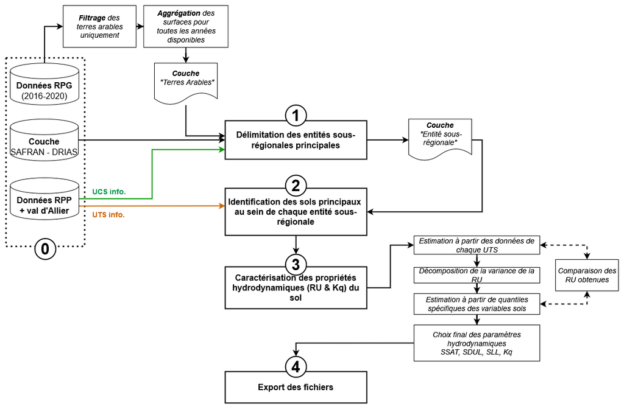

La chaine d’analyse proposée est la suivante:

0. **Préparation des données d’entrée**
1. **Délimitation des entités sous-régionales** à l’échelle de la Limagne 1.0. Création d’une couche “terres arables” pour chaque maille 1.1. Création d’une couche “entités sous-régionales” par regroupement de mailles
2. **Identification des sols principaux au sein de chaque entité sous-régionale**
3. **Caractérisation des propriétés hydrodynamiques** 3.1. Calcul de la RU et du coefficient de percolation (Kq) pour chaque unité de sol (UTS) 3.2. Décomposition de la variance de la RU 3.3. Proposition d’un triplet de “profil de sol typique” pour chaque entité sous-régionale établi sur la base des quantiles des attributs du sol 3.4. Evaluation des triplets
   4. **Export des fichiers** formatés pour utiliser un modèle de culture

## 0.3 Description des données d’entrée et mise en forme préalable

L’approche proposée repose sur les jeux de données suivants:

- les **limites géographiques de la Limagne** - il s’agit d’une délimitation des communes appartenant à la Limagne, telle que définie pour les ‘petites régions agricoles’. En quelques mots, le territoire de la Limagne considéré s’étend sur toute la plaine et les collines comprises entre Moulins et Brioude.
- les **mailles DRIAS-Safran** - il s’agit d’un maillage spatial d’une résolution de 8x8 km sur l’ensemble du territoire francais. C’est sur la base de cette résolution spatiale que sont proposées es données climatiques historiques (Safran) et projetées pour différents scénarios régionalisés de changement climatique (DRIAS). La Limagne recouvre 82 mailles DRIAS-Safran.

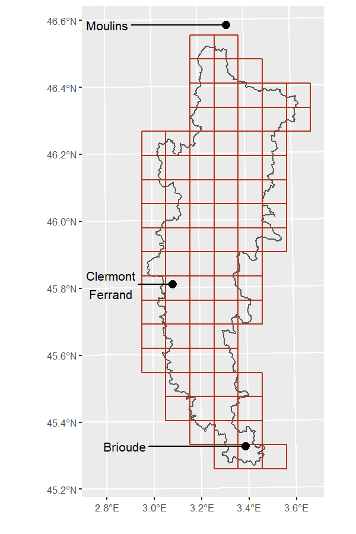

- les **données du Registre Parcellaire Graphique (RPG)** - ces données, définies pour chaque année, décrivent la spatialité des parcelles agricoles ainsi que la culture en place (en lien avec les déclaration PAC). Les données de la période 2016-2020 ont été mobilisées pour la présente étude. Pour définir les terres arables potentielles, on a uniquement considéré les surfaces qui ont été mise en culture avec l’un des groupes de culture suivant :

| Code groupe culture (RPG) | Description |
| --- | --- |
| 1 | Blé tendre |
| 2 | Maïs grain et ensilage |
| 3 | Orge |
| 4 | Autres céréales |
| 5 | Colza |
| 6 | Tournesol |
| 7 | Autres oléagineux |
| 8 | Protéagineux |
| 9 | Plantes à fibres |
| 15 | Légumineuses à graines |

Tous les autres groupes de cultures ont été exclus, à savoir des surfaces en prairie permanente ou temporaire, des cultures fourragères, des vignes, des vergers… Toutes les surfaces concernées au cours de la période 2016-2020 ont ensuite été fusionnées. On a alors obtenu la couche suivante :

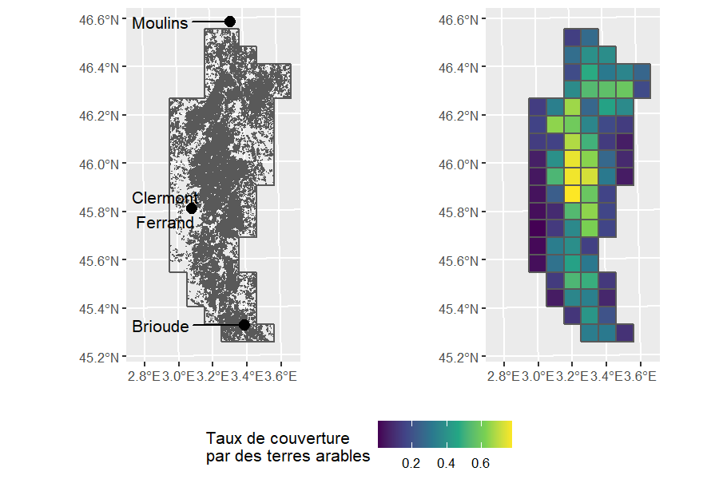

Les surfaces concernées montrent une forte concentration des terres arables dans la plaine de Limagne et tout le val d’Allier. Les zones de côteaux présentent elles des zones cultivées plus éparses.

- les **données du Réseau Régional Pédologique (RRP)** - il s’agit de données pédologiques établies à l’échelle départementale. Les données à disposition concernent les département de l’Allier (03) et du Puy de Dôme (63). En revanche, il manque des données pour la partie Sud de la Limagne (7 cellules sont concernées, en Haute Loire, où le RRP n’est pas encore disponible). Les données mobilisées sont essentiellement la **profondeur de sol et la texture**. Des données partielles (et anciennes) de densité apparente et de teneur en matière organique (MO) sont également présentes. L’information pédologique se structure en différent unité spatiale, à savoir les UCS (*Unité Cartographique de Sol*), elles même composées d’une ou plusieures UTS (*Unité Typologique de Sol*). Les UCS renseignent essentiellement sur la spatialité des unités de sol (*i.e* position et surface), tandis que les UTS décrivent (quantitativement et qualitativement) la nature du sol (selon une description d’un profil de sol).
- les **données du val d’Allier** - il s’agit de données pédologiques pour tout le val d’Allier, établie en 1967. Ces données, moins précises et formatées différemment, ont été mobilisées pour obtenir de l’information sur les Sud du territoire de la Limagne. L’information pédologique se structure ici uniquement en UCS, qui contiennent alors à la fois les informations spatiales et descriptives de la nature du sol. Enfin, les informations quantitatives concernent uniquement l’horizon supérieur (0-30 cm).

Les deux jeux de données spatialisées ont été combinés pour disposer des données du RRP partout où il était disponible (Allier et Puy de Dôme), sinon ce sont les informations contenus dans les donnéees du val d’Allier qui ont été considérées (Haute-Loire).

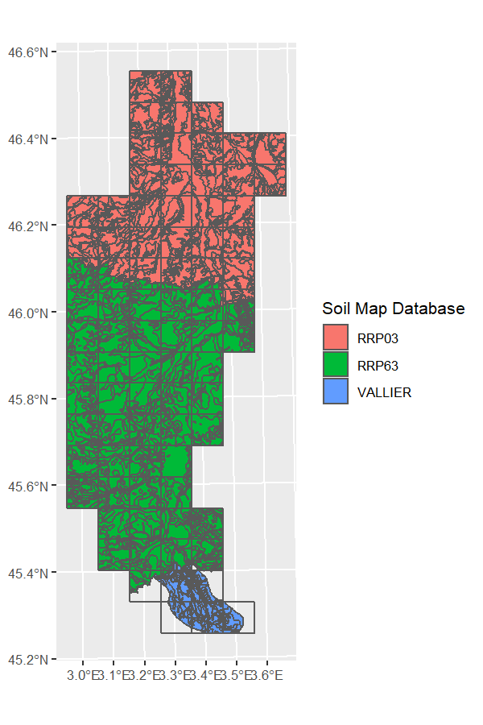

Enfin, la **B**ase de **D**onnées des **A**nalyses de **T**erres (BDAT) a été mobilisée pour obtenir des données relativement récentes concernant la teneur en MO, dont une estimation est nécessaire pour le calcul de la teneur en eau à saturation. Ces données sont décrites à l’échelle du canton et concernent essentiellement l’horizon supérieur du sol (0-30 cm). Les jeux de données disponibles compilent les analyses de sol pour des périodes de 5 années (1995-1999, 2000-2004, 2005-2009, 2010-2014) et sous forme de quantiles statistiques. Pour chaque canton, la médiane la plus récente a été retenue. Les données ont ensuite été reprojetées sur chaque cellule en pondérant par la surface de chaque canton.

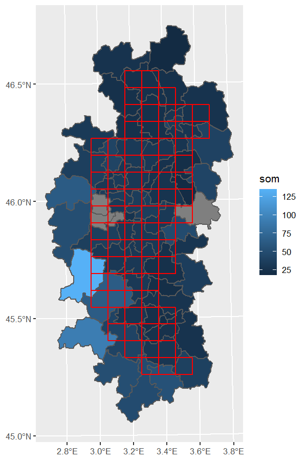

# 1. Définition des entités sous-régionales

Afin de simplifier l’analyse spatiale sur le territoire, nous proposons de travailler à l’échelle d’entités sous-régionales. Ces entités regroupent plusieures cellules adjacentes partageant des caractéristiques pédologiques relativement communes. L’idée sous-jacente est de réduire les travaux de modélisation à un ensemble de zones réduites (une dizaine au maximum), plutôt que de les réaliser sur l’ensemble des 82 mailles.

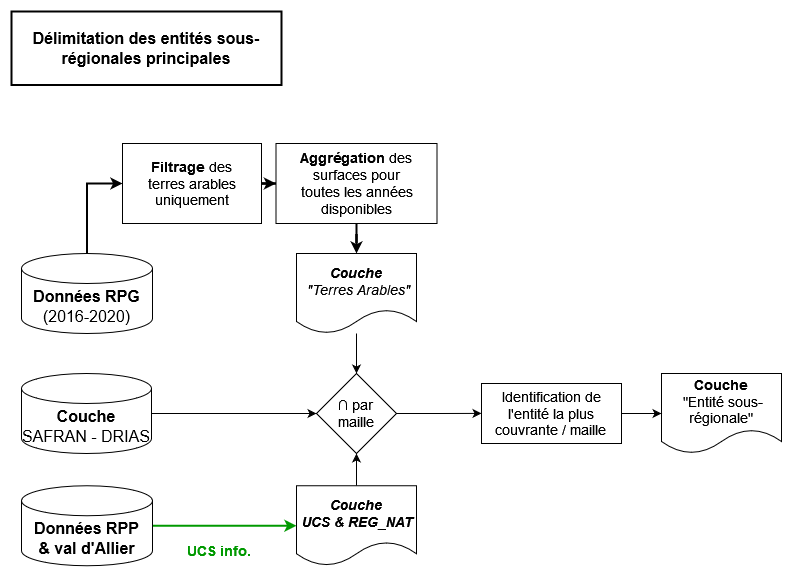

Pour définir ces entités sous-régionales, nous avons mobilisé la variable REG_NAT (*i.e.* “petite **REG**ion **NAT**urelle”) décrite au sein du jeu de données du RRP. Dans cette couche spatiale, chaque UCS est affiliée à une région naturelle spécifique. Elles sont définies par les pédologues du RRP à partir d’éléments décrivant :

- la géologie locale
- la géomorphologie
- le climat local
- le “paysage rural”
- la pédologie locale

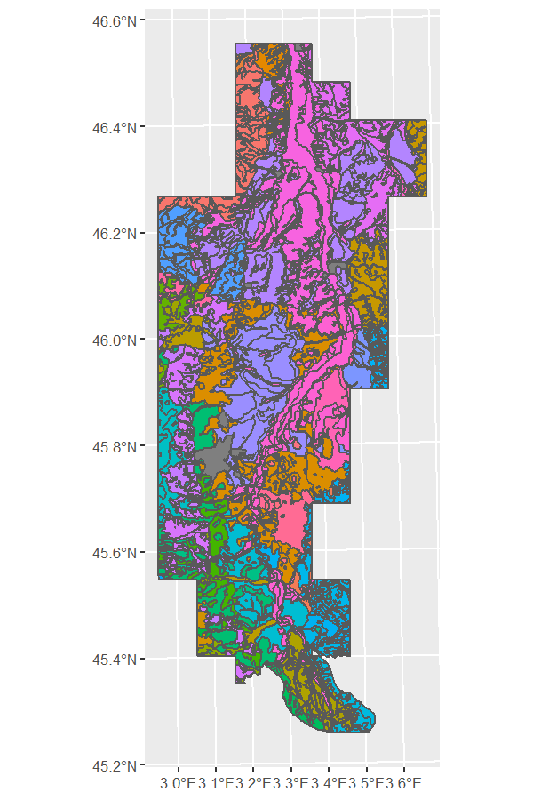

Pour les mailles situées en Haute-Loire (*i.e.* dépendantes de la base de données du val d’Allier), cette variable étaient absente. Une nouvelle variable REG_NAT a été créée “à la main”, en considérant quatres grandes entités sous-régionales, à savoir :

- les côteaux Ouest
- la zone alluviale, située à proximité immédiate de l’Allier
- la zone de plaine/colline centrale, située en périphérie du val d’Allier
- les côteaux Est

On a attribué un nom à chacune de ces entités sous-régionales en analysant le noms des entités sous-régionales au Nord, et qui semblait alors se prolonger dans les cellules de Haute-Loire.

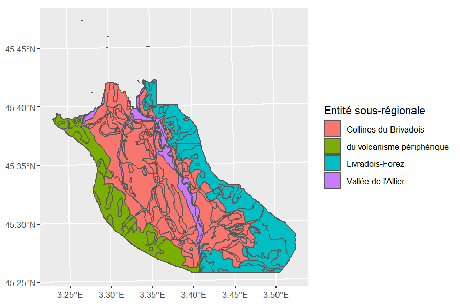

On dénombre 38 petites régions naturelles (REG_NAT) à l’échelle du territoire considéré. Pour assigner une seule valeur par maille, le taux de couverture de chaque entité régionale a été calculé puis classé. L’entité la plus couvrante a été attributée à chaque maille. Afin de limiter le nombre d’entités sous-régionales à un nombre raisonnable, certaines entités ont été fusionnées entre elles, sur la base d’une cohérence géomorphologique et pédologique (i.e. on a vérifié la cohérences au niveau des types de sol) :

| Code | Nom de l’ entité sous-régionale | Nom de la petite région naturelle (reg_nat) associée |
| --- | --- | --- |
| 1 | Rebord Ouest des Limagnes | - Combraille > 600 m - Combrailles - Cézallier - Du socle de l’Artense, du Cézallier et des rebords des massifs volcaniques - Du volcanisme périphérique ponctuel et issu des massifs - GDM du volcanism… |
| 2 | Collines du Brivadois | - Collines du Brivadois |
| 3 | Collines et côteaux bordiers des bassins de Limagne | - Bocage bourbonnais - Basse Combraille - Moyenne Combraille - Collines bourbonnaises - Bordures des bassins de Limagne - Pays entre Dore et Allier - Volcanisme en Limagne - Collines des rebords Ouest… |
| 4 | Dépôts sédimentaires et alluviaux de l’Allier et de ses affluents | - Val d’Allier - Vallée de la Besbre et petites vallées affluentes de la Loire - Vallée de l’Allier - Vallée de la Dore - Vallée de la Sioule - Couze et vallées encaissées - Des vallées encaissées et … |
| 5 | Limagnes méridionales et Lembronnais | - Limagnes méridionales et Lembronnais - Des sédiments périphériques aux Limagnes |
| 6 | Livradois -Forez | - Livradois-Forez - Livradois-Forez - Montagnard inférieur sur granite - Livradois-Forez - Montagnard inférieur sur gneiss - Livradois-Forez - Valléees et vallons du Montagnard inférieur |
| 7 | Plaine marneuse de Limagne | - Plaine marneuse de Limagne |
| 8 | Plaines et collines marno-calcaires de Limagne | - Plaines et collines calcaires de Limagne - Sologne Bourbonnaise |

Après l’analyse spatiale des surfaces agricoles et de leur appartenance à une petite région naturelle, on obtient la classification suivante :

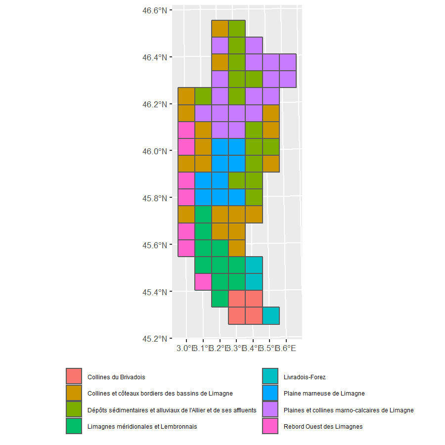

**NB : Cette étape a un impact conséquent sur tout le reste de l’analyse. Il nécessite d’être validée par des pédologues régionaux.**

# 2. Identification des sols principaux de chaque entité régionale

Au sein de chaque entité sous-régionale, ont été retenus les types de sols permettant de couvrir à minima 50% de la zone d’intérêt.

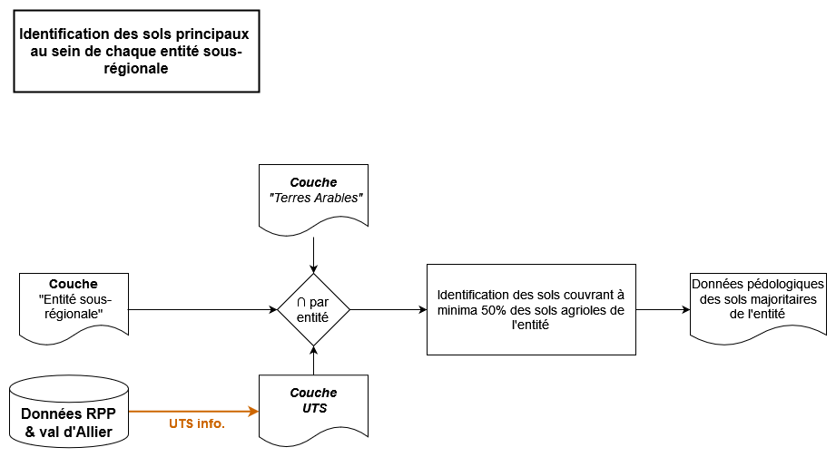

Voici un exemple appliqué au sein d’une entité régionale, la “Plaine marneuse de Limagne” :

| Type de sols présents | [%] surfacique des terres agricoles | Cumul [%] surfacique | Type de sols conservés |
| --- | --- | --- | --- |
| Calcosols | 37.4 | 37.4 | Calcosols |
| Vertisols | 21.4 | 58.8 | Vertisols |
| Colluviosols | 18.3 | 77.1 |  |
| Brunisols | 13.6 | 90.7 |  |
| Calcisols | 3.6 | 94.3 |  |
| Fluviosols | 2.4 | 96.7 |  |
| … (7 autres types mino ritaires) | 3.3 | 100 |  |

Le tableau suivant synthétise les types de sols “majoritaires” et retenus pour chaque entité sous-régionale.

[output not shown]

Nous avons ensuite vérifié que les sols considérés pour le reste de l’étude sont relativement similaires du point de vue de la texture.

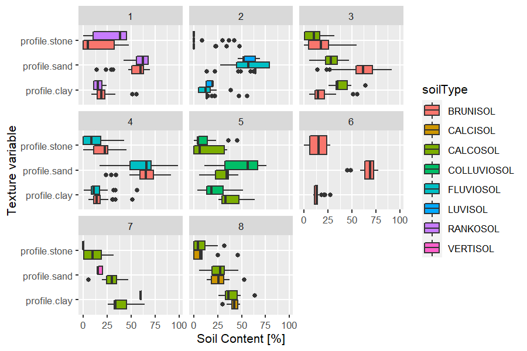

C’est globalement satisfaisant. On remarque malgré tout que les groupes 3 (“*Collines et côteaux bordiers des bassins des Limagnes*”), 5 (“*Limagnes méridionales et Lembronnais*”) et 7 (“*Plaine marneuse de Limagne*”) présentent des différences marquées au niveau des teneurs moyennes en sable et en argile.

# 3. Caractérisation des propriétés hydrodynamiques des sols de Limagne

Le fonctionnement hydrique des sols au sein des modèles de cultures nécessitent de décrire un certain nombre de propriétés hydrodynamiques. En particulier, le modèle Sirius requiert la description pour chaque horizon du sol de:

- la teneur en eau à la capacité au champ ($\theta_{FC}$, avec FC - *field capacity*) (paramètre Sirius: SDUL)
- la teneur en eau au point de flétrissement permanent ($\theta_{PWP}$, PWP - *permanent wilting point*) (paramètre Sirius: SLL)
- la teneur en eau à saturation ($\theta_{sat}$) (paramètre Sirius: SSAT)

Un paramètre est également requis pour l’ensemble du profil de sol :

- un coefficient de percolation ($Kq$) (paramètre Sirius: Kq)

Dans un premier temps, nous mobilisons les données du RRP et du Val d’Allier pour estimer SDUL, SSL, Kq et des profils de sol représentatifs de chaque entité régionale.

Dans un second temps, nous mobilisons également les données du BDAT pour estimer SSAT.

## 3.1 Estimation de SDUL, SSL, Kq et choix des profils de sol représentatifs

### 3.1.0 Chaine d’analyse proposée pour chaque entité sous-régionale

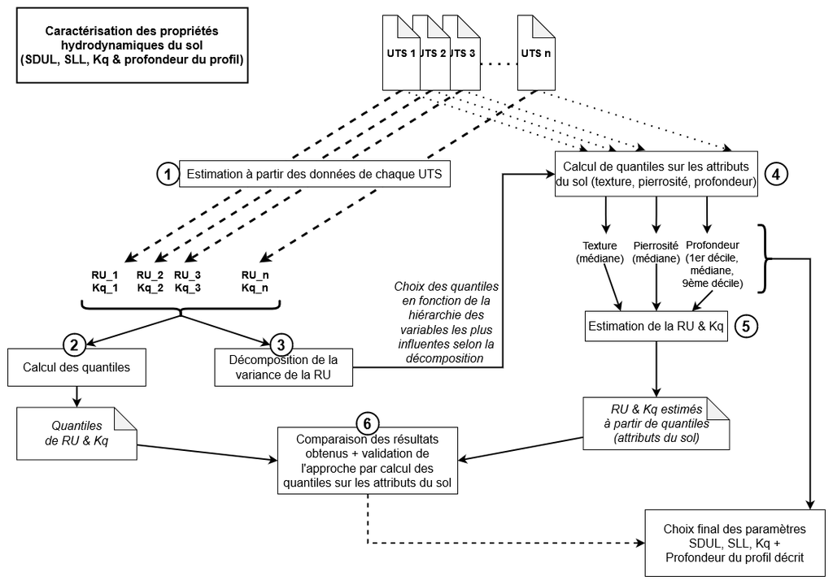

### 3.1.1 Formalismes mobilisés

#### Calcul de la réserve utile

La réserve utile a été calculée selon l’équation suivante :

$$RU =
\sum_{i=1}^{n}(\frac{100-\tau_{cailloux,i}}{100} \cdot \epsilon_i \cdot
\frac{\theta_{FC,i} - \theta_{PWP,i}}{100} \cdot 10^3 )$$

où :

- $n$ est le nombre d’horizons de sol décrits
- $\tau_{cailloux}$ est le taux de pierrosité au sein de la couche de sol [%vol]
- $\epsilon_i$ est l’épaisseur de l’horizon i au sein du profil de sol [m]
- $\theta_{FC}$ est la teneur en eau du sol à la capacité au champ (pF = 0.33) [%vol]
- $\theta_{PWP}$ est la teneur en eau du sol au point de flétrissement permanent (pF = 4.2) [%vol]

$\theta_{FC}$ et $\theta_{PWP}$ ont été estimés à partir des données de texture. L’estimation a été faite d’après les fonctions de pédotransfert établies à l’échelle de la France par [Román Dobarco et al. (2019)](https://www.sciencedirect.com/science/article/pii/S0016706118307171?via%3Dihub). Plusieures équations sont proposées par les auteurs, en fonction i) de la description des horizons du sol (par horizon ou pour un profil complet), ii) du type de données disponibles (intervalles de valeurs ou variables continues) et iii) des données disponibles (à minima teneur en sable et en argile, facultativement densité apparente et teneur en MO). Parmi les modèles proposés par Román Dobarco et al. (2019), nous avons choisi un modèle simple :

- qui mobilise la texture du sol de façon continue,
- qui ne prend pas en compte ni la teneur en MO, ni la densité apparente, car les données disponibles pour ces deux attributs sont partielles et/ou trop anciennes (voir commentaires supplémentaires vis à vis de la MO et de l’estimation de $\theta_{sat}$)
- qui ne nécessite pas de préciser le type d’horizon considéré (e.g. avec une distinction pour l’horizon de surface) pour que le modèle puisse être mobilisé sur des valeurs moyennes ou médianes, décrivant le profil complet

Les équations mobilisées sont :

$$\theta_{FC} = 0.278 + 2.45 \cdot
10^{-3} \cdot [Argile] - 1.35\cdot 10^{-3} \cdot [Sable]$$

$$\theta_{PWP} = 0.080 + 4.01 \cdot
10^{-3} \cdot [Argile] - 2.93\cdot 10^{-4} \cdot [Sable]$$

où $[Argile]$ et $[Sable]$ sont les teneurs respectives exprimées en $[\%]$.

Enfin, la prise en compte de la pierrosité dans le calcul de la RU est un choix. La proportion de cailloux atteint parfois des valeurs non négligeables dans certains sols - il nous semblait donc important de cet aspect en compte. Une conséquence immédiate de la présence de cailloux dans un sol est la réduction du volume de terre fine d’un sol, diminuant immanquablement la RU. Toutefois, certains auteurs ont montré que les cailloux d’un sol peuvent contribuer positivement à la RU d’un sol en restituant progressivement de l’humidité à la fraction de terre fine du sol ou en modifiant les propriétés relative à l’infiltration (e.g. [Fiès et al. 2002](https://bsssjournals.onlinelibrary.wiley.com/doi/full/10.1046/j.1365-2389.2002.00431.x) ; [Cousin et al. 2003](https://www.sciencedirect.com/science/article/pii/S0341816203000377) ; [Tetegan et al. 2011](https://www.sciencedirect.com/science/article/pii/S001670611100190X) ; [Robertson et al. 2021](https://www.sciencedirect.com/science/article/pii/S0016706120326677)). Dans notre cas, nous avons considéré que les cailloux du sol étaient inertes et modifiaient uniquement la RU en réduisant le volume de fraction de terre fine.

#### Coefficient de percolation Kq

Le coefficient de percolation a été estimé selon le formalisme proposé par [Addiscott and Whitmore (1991)](https://bsssjournals.onlinelibrary.wiley.com/doi/abs/10.1111/j.1475-2743.1991.tb00856.x). Il est estimé uniquement à partir de la teneur en argile du sol à partir des équations suivantes :

$$K_q = 1 \hspace{10em} ; \space [Argile]
\leq 9.5 \\
K_q = 1.0271 - 0.000302 \cdot [Argile]^{2} \hspace{1em} \space ;
\space 9.5 < [Argile] < 58.3 \\
K_q = 0 \hspace{10em} \space ; \space [Argile] \geq 58.3$$

où $[Argile]$ est la teneur en argile du sol en $[\%]$.

#### Décomposition de la variance

Afin de mieux comprendre la hiérarchie des facteurs impliqués dans l’observation d’une gamme de RU à l’échelle du territoire, nous proposons de décomposer la variance de celle ci. L’équation de la RU (présentée en 3.1) est un produit de facteurs que l’on peut noter:

$$RU = Z_{prof} \cdot T_{pierrosité}
\cdot \Theta_{texture}$$
où $Z_{prof}$ est la profondeur du profil complet, $T_{pierrosité}$ est la pierrosité globale du profil, et $\Theta_{texture}$ est la fraction d’eau transpirable, à savoir la différence entre $\theta_{FC}$ et $\theta_{PWP}$ intégré sur tout le profil.

En appliquant le logarithme, on obtient :

$$log(RU) = log(Z_{prof}) +
log(T_{pierrosité}) + log(\Theta_{texture})$$

On peut alors décomposer la variance de la RU tel que :

$$var(log(RU)) = var(log(Z_{prof})) +
var(log(T_{pierrosité})) + var(log(\Theta_{texture}))$$

### 3.1.2. Vérifications méthodologiques

#### Influence de la qualité des données disponibles

Les informations pédologiques disponibles proviennent de 3 sources de données différentes. Cela questionne l’harmonisation des données entre elles et d’un possible impact sur l’estimation de certains paramètres. En particulier, le niveau de description entre les données issues des RRP (description par profil) et du val d’Allier (description uniquement pour l’horizon supérieur) diffère.

C’est particulièrement problématique pour deux entités sous-régionales, à savoir :

- les Collines du Brivadois
- le Livradois Forez (dans une moindre mesure car la plupart des sols sont décrits via le RRP)

Afin d’avoir un ordre de grandeur de l’erreur possible, nous proposons de regarder quel est l’impact sur l’estimation de la RU lorsque l’on alloue la texture de l’horizon supérieur (entre 0 et 30 cm) pour tout le profil de sol évalué. On observe:

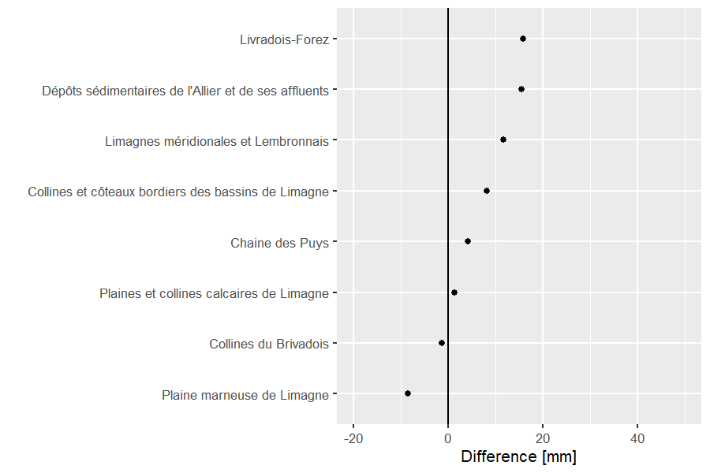

La RU d’un profil de sol complet risque d’être légèrement surestimée lorsque l’on se base uniquement sur la texture de l’horizon supérieur. Bien que cela soit dépendant des sols considérés au sein de chaque entité sous-régionale, l’erreur reste malgré tout acceptable (< 20 mm).

#### Choix des facteurs pris en compte dans le calcul de la RU

Nous avons évalué quel était l’influence de la méthode de calcul de la RU et des facteurs pris en compte, à savoir :

1. quel est l’impact de la méthode de discrétisation des horizons du sol ? Autrement dit, existe t’il une différence au niveau de la RU si i) elle est calculée comme la somme des RU de chaque horizon, ou si ii) elle est calculée comme le produit d’attributs du sol moyennés pour tout le profil du sol.
2. quel est l’impact de la prise en compte de la pierrosité dans le calcul de la RU ?

Réponse à la 1<sup>ère</sup> question méthodologique : Dans le cadre de notre étude, calculer la RU comme une somme de RU pour chaque horizon ou en considérant des valeurs moyennes pour tout le profil n’a pas d’influence :

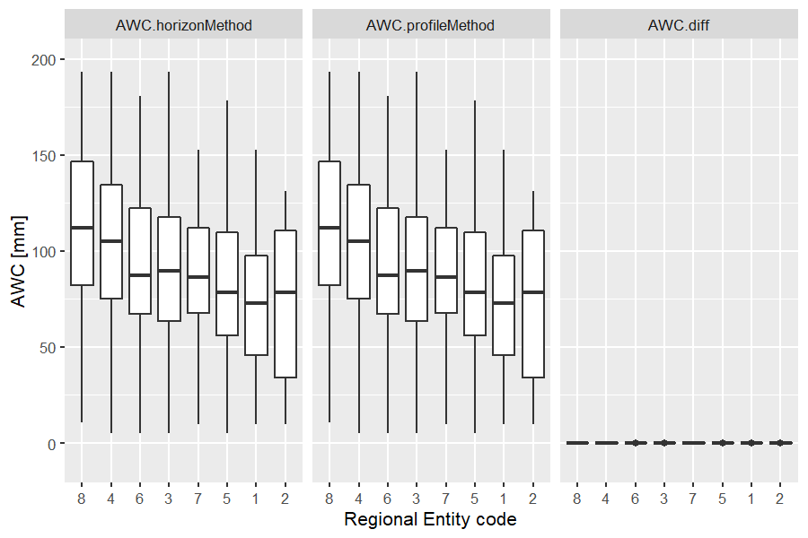

On explique le fait qu’il n’y ait pas du tout de différence entre les deux méthodes de calcul par le fait que:

- l’équation de pédotransfert utilisée est linéaire
- la texture pour le profil du sol est une moyenne pondérée par les épaisseurs de chaque horizon du sol

Cela rend les approches strictement similaires d’un point de vue mathématique (cela peut être démontré). Nous proposons par conséquent de poursuivre l’analyse à l’échelle d’un profil de sol complet.

Il semble par ailleurs compliqué de proposer une méthode pour décrire un sol stratifié médian pour chaque entité régionale. Nous proposons donc de décrire les sols comme des sols avec un unique horizon homogène.

Réponse à la 2<sup>ème</sup> question méthodologique : L’analyse de la prise en compte de la pierrosité ou non sur le calcul de la RU montre que c’est un facteur qui a une influence non négligeable sur l’ensemble des entités sous-régionales:

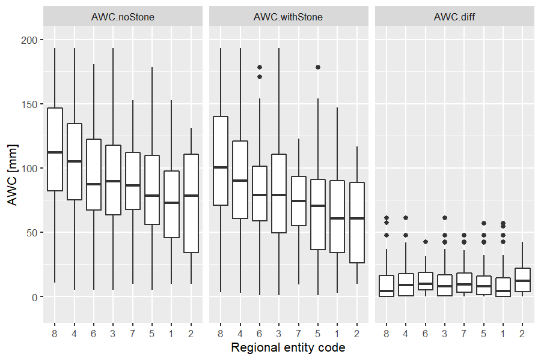

Par conséquent, nous proposons de conserver cette information pédologique lors du calcul de la RU.

### 3.1.3 Etapes 1 et 2: Calcul de la RU pour chaque UTS

Pour chaque entité sous-régionale, on a calculé une RU pour chaque UTS. Puis connaissant la surface occupé par chaque UTS au sein des surfaces cultivées, nous en avons déduit des distributions de RU au sein de chaque entité.

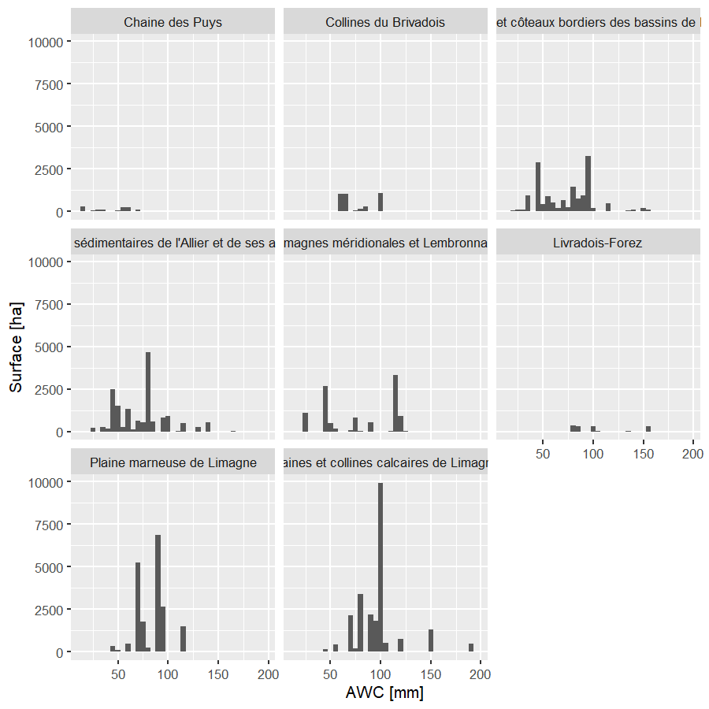

C’est à partir de ces distributions que nous avons ensuite calculé la valeur du 1er décile, de la médiane, et du 9ème décile.

### 3.1.4 Etape 3: Décomposition de la variance de la RU

La décomposition de la variance a été réalisée sur :

- l’ensemble des UTS considérées, sans distinction de l’entité régionale (histogramme de gauche)
- l’ensemble des UTS considérées, au sein de chaque entité régionale (histogramme de droite)

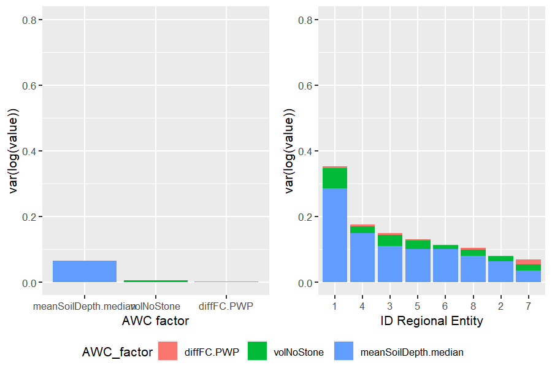

Dans les deux cas, on montre que la profondeur du sol est le premier facteur de variabilité de la RU en plaine de Limagne, suivi par la pierrosité. La texture est un facteur de variation relativement mineur en comparaison des deux autres facteurs. A noter que la texture peut devenir un facteur de variation plus important si la profondeur des sols est relativement homogène et avec un taux de pierrosité faible : c’est par exemple le cas de la “*Plaine marneuse de Limagne*” (ID = 7 ; histogramme de droite).

### 3.1.5 Etapes 4 et 5 : Proposition d’un triplet de sol pour chaque entité régionale

La décomposition de la variance nous montre que la profondeur de sol est le facteur de variation principal pour la RU à l’échelle de la Limagne, quelque soit l’échelle considérée. Par conséquent, nous proposons de créer un triplet de valeurs de RU pour représenter la gamme de variation observée, en se basant sur des estimations des valeurs de la médiane de la RU ainsi que des premier et neuvième déciles (qui couvrent ainsi 80% des sols agricoles conservés à cette étape). Nous proposons les approximations suivantes:

$$RU_{0.5 \cdot médiane} = T_{pierrosité, médiane} \cdot \Theta_{texture,
médiane} \cdot 0.5 \cdot Z_{prof, médiane} \\
RU_{1er \space décile} = T_{pierrosité, médiane} \cdot \Theta_{texture,
médiane} \cdot Z_{prof,1er \space décile} \\
RU_{médiane} = T_{pierrosité, médiane} \cdot \Theta_{texture, médiane}
\cdot Z_{prof,médiane} \\
RU_{9ème \space décile} = T_{pierrosité, médiane} \cdot \Theta_{texture,
médiane} \cdot Z_{prof,9ème \space décile} \\
RU_{1.5 \cdot médiane} = T_{pierrosité, médiane} \cdot \Theta_{texture,
médiane} \cdot 1.5 \cdot Z_{prof, médiane}$$

On obtient alors pour la RU de chaque entité sous-régionale :

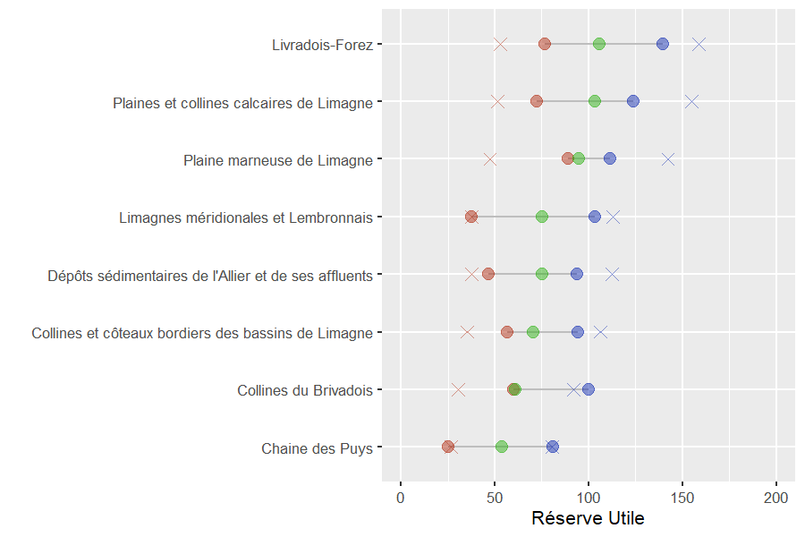

En revanche, un seul coefficient de percolation $K_q$ par entité sous-régionale est proposé, en le calculant à partir du taux d’argile médian :

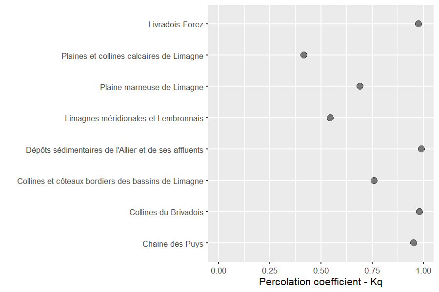

### 3.1.6 Etape 6 : Evaluation des triplets choisis

#### Comparaison des triplets avec les ‘vrais’ quantiles statistiques

Pour la RU :

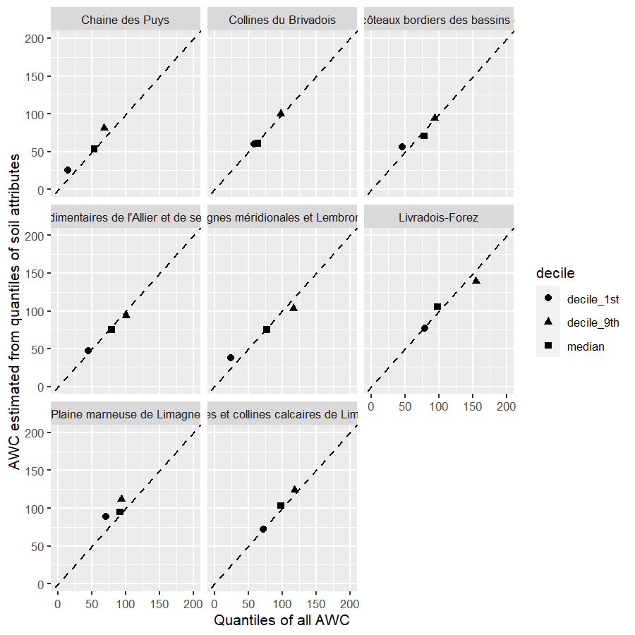

Pour Kq:

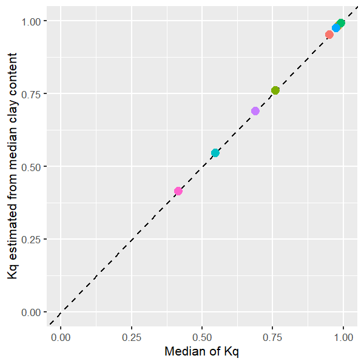

#### Aparte : Comparaison avec les données fournies par Siclima

[Siclima](https://agroclim.inrae.fr/siclima/) est une interface Web mise au point par l’INRAE (UMR AgroClim) qui met à disposition des données climatiques sur le maillage proposée. Siclima propose aussi des valeurs pour les paramètres hydrodynamiques du sol de chaque maille ([plus d’informations sur cette page](https://agroclim.inrae.fr/siclima/help/extraction/creation/sel_mailles.html#choisir-les-mailles-avec-leurs-attributs)). Nous avons souhaité comparer les informations “sol” fournies par Siclima et celles que nous avons calculées.

Pour l’estimation de la RU, il s’avère que des différences notables entre les deux jeux de données ressortent.

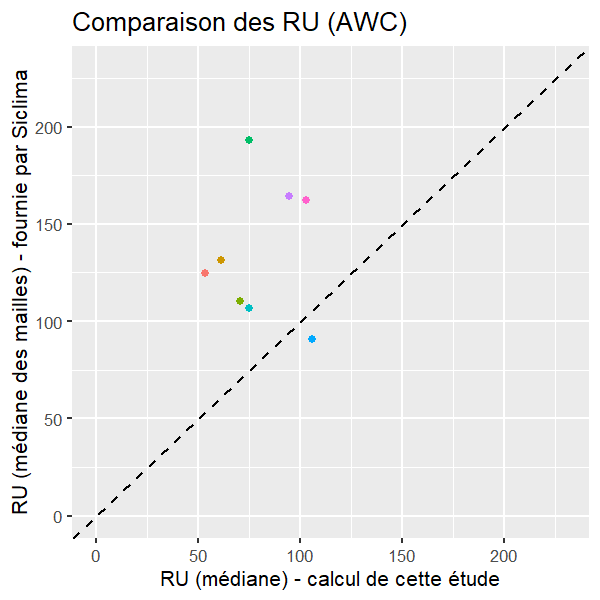

- les effets liés à la profondeur
- les effets liés à la texture (*i.e* lors du calcul de $\theta_{FC}$ et $\theta_{PWP}$)
- les effets liés à la pierrosité
- un éventuel effet lié au calcul de la texture (*i.e* on considére que la texture de l’horizon supérieur est valable pour tout le profil)

Pour les effets liées à la profondeur, on observe:

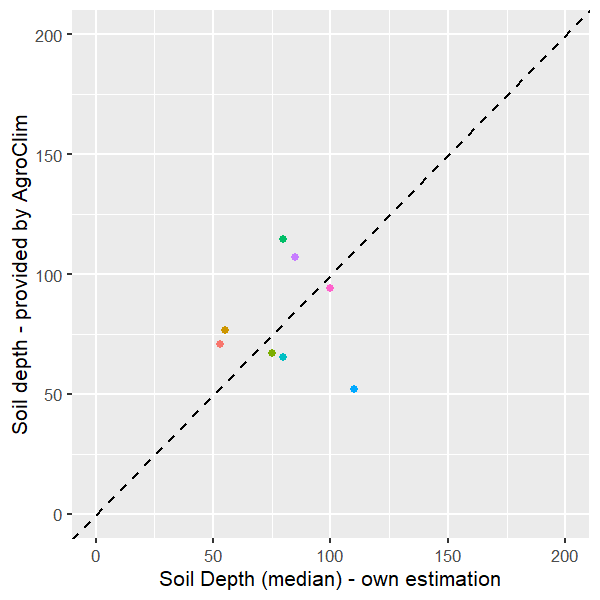

La profondeur ne semble donc pas être le facteur principalement mis en cause.

Pour les effets liés à la texture et à la pierrosité, on observe:

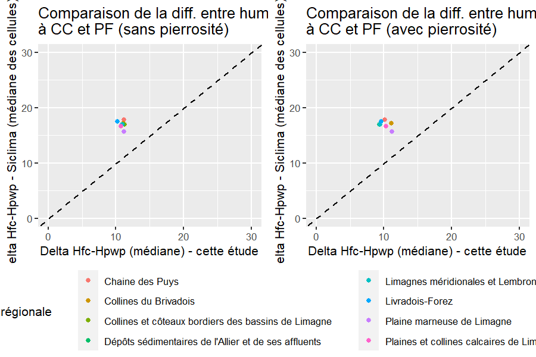

La différence semble provenir de la texture. La pierrosité n’a que peu d’influence visiblement.

Si l’on regarde l’effet d’une prise en compte uniquement de la texture de l’horizon supérieur, on observe:

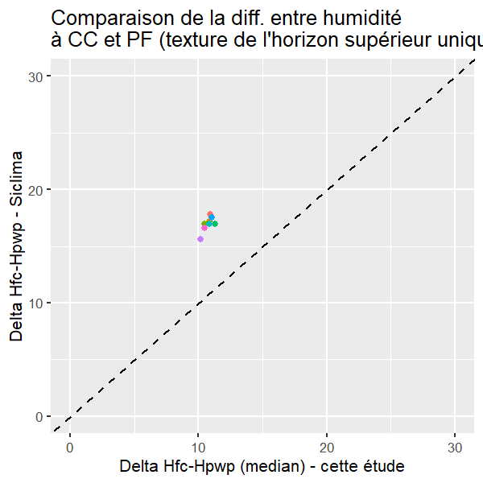

Cela ne semble pas être la cause des différences observées.  
On peut seulement conclure que des estimations de texture ou de courbes de pédotransfert utilisées sont la source principale des différence observées au niveau de la RU entre le jeu de données Siclima et celui de cette étude.

## 3.2 Estimation de la teneur en eau à saturation

### 3.2.1 Chaine d’analyse proposée pour chaque entité sous-régionale

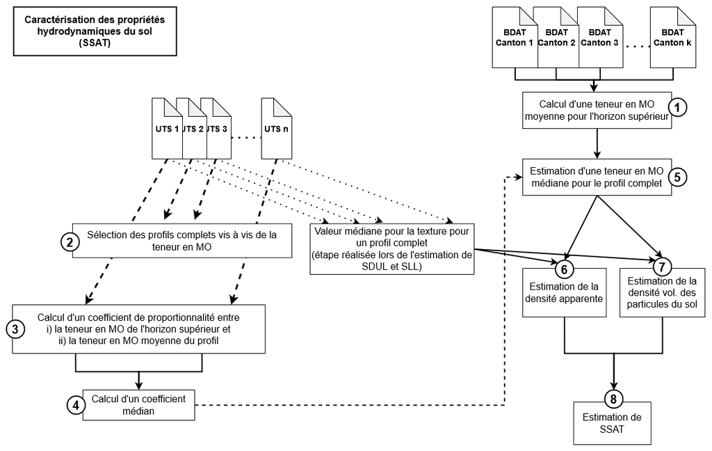

### 3.2.2 Formalisme général

La teneur en eau d’un sol à saturation ($\theta_{sat}$) correspond à la teneur en eau d’un sol lorsque tous les pores sont occupés. Cela se traduit par l’équation suivante :

$$\theta_{sat} = 1 - f_{V_{particule}} =
1 - \frac{DA}{\rho_{particule}}$$

où :

- $f_{V_{terre fine}}$ est la fraction volumique des particules fines du sol [-]
- $DA$ est la densité apparente du sol [g.cm<sup>-3</sup>]
- $\rho_{particule}$ est la densité volumétrique des particules fines du sol [g.cm<sup>-3</sup>]

Tous les formalismes permettant d’estimater $DA$ et $\rho_{particule}$ nécessitent d’avoir une estimation de la teneur en MO.

#### a. Estimation de la densité apparente

Les données de densité apparente sont trop partielles pour pouvoir être exploitées. Nous avons choisi de l’estimer à partir du formalisme proposé par [Keller et al. (2010)](https://www.sciencedirect.com/science/article/pii/S0016706109003644?via%3Dihub). Parmis les équations proposées, la plus parcimonieuse nécessite des données sur la texture du sol et la teneur en matière organique (MO), tel que :

$$DA = 1.308 + 0.0119 \cdot [Argile] +
0.0103 \cdot [Sable] - 0.00018 \cdot [Argile]^2 \\ - 0.00008 \cdot
[Sable]^2 - 0.00062 \cdot [Limon] \cdot [MO] - 0.00059 \cdot [Sable]
\cdot [MO]$$

où $[Argile]$,$[Sable]$,$[Limon]$ et $[MO]$ sont les teneurs respectives de chaque fraction texturale du sol exprimée en $[\%]$.

Cette estimation de la densité apparente est généralement mobilisé pour estimer une densité apparente dite ‘*de référence*’, supposant que le sol étudié n’est pas compacté sous l’action des machines agricoles.

#### b. Estimation de la densité des particules du sol

Pour $\rho_{particle}$, deux options sont envisageables, à savoir:

- considérer une valeur fixe de 2.65 $[g.cm^{-3}]$ (*i.e* la densité du quartz) ; mais cette approche est considérée comme grossière en présence d’une certaine diversité de sols ([Rühlmann,2020](https://www.sciencedirect.com/science/article/pii/S0016706120306443))
- considérer un gradient de valeurs en fonction de la texture du sol - une estimation est alors possible selon le modèle proposé par [Schjonning et al. (2017a)](https://www.sciencedirect.com/science/article/pii/S001670611630636X?via%3Dihub) et recalibré par [Rühlmann (2020)](https://www.sciencedirect.com/science/article/pii/S0016706120306443). L’estimation se base sur les données de texture du sol et de teneur en MO. Le formalisme proposé est :

$$\rho_{particle} = \Biggl[
\frac{f_{SM_{sol}}}{\rho_{SM_{sol}}} +
\frac{f_{MO_{sol}}}{\rho_{MO_{sol}}} \Biggl]^{-1}= \Biggl[
\frac{f_{SM_{sol}}}{a+b \cdot f_{Argile}} + \frac{f_{MO_{sol}}}{c+d
\cdot f_{MO_{sol}}} \Biggl]^{-1}$$

où $f_{SM_{sol}}$ est la fraction en **S**ubtance **M**inérale d’un sol en $[kg.kg_{sol}^{-1}]$ ; $f_{MO_{sol}}$ la fraction en Matière Organique d’un sol $[kg.kg_{sol}^{-1}]$ tel que $f_{MO_{sol}} = 1 - f_{SM_{sol}}$ ; et $f_{argile}$ est la proportion d’argile dans la fraction minérale $[kg.kg_{SM}^{-1}]$

Rühlmann (2020) a recalibré les coefficients {a,b,c,d} sur un plus grand jeux de données que Schjonning et al. (2017a) et propose :

$$a = 2.663 \space ; \space b = 0.107 \\
c = 1.241 \space ; \space d = 0.173 \\$$

#### c. Estimation de la teneur en MO du sol

Dans la base de données du RRP ou du Val d’Allier, des teneurs en carbone organique (Corg) ou en matière organique (MO) sont fournies. Cependant de nombreuses valeurs sont absentes parmi les profils de sol décrits et, de surcroit, les valeurs disponibles sont discutables. Les données sont jugées trop anciennes pour être représentatives de la situation actuelle (Benjamin Nowak, communication personnelle). A noter que les dates de prélèvement des échantillons sont rarement mentionnées au sein des 2 RRP mobilisés.

Par conséquent, nous avons choisi de mobiliser le moins possible la teneur en MO pour l’estimation des paramètres hydrauliques, sauf pour $\theta_{sat}$ où tous les formalismes trouvés l’exigaient.

Pour estimer ce paramètre, nous proposons de le faire en dernier lieu, sur la base d’un profil de sol simplifié (un pour chaque entité sous-régionale), une fois le travail d’estimation de $\theta_{FC}$ et $\theta_{PWP}$) réalisé et les textures du profil de sol établies.

Pour estimer la teneur en MO à l’échelle d’une entité régionale, nous avons procédé comme suit : 1. la teneur en MO médiane de l’horizon supérieur est déduite à partir des données du BDAT pour chaque entité régionale 2. à partir de tous les profils de sol existants et complets dans une entité régionale, nous estimons un coefficient (médian) pour estimer la teneur en MO moyenne d’un profil de sol à partir de la teneur en MO de l’horizon supérieur 3. la teneur en MO du profil simplifié (à l’échelle de l’entité régionale) est calculé à partir des valeurs obtenues en (1) et (2). 4. on calcule $DA$, $\rho_{particule}$ et enfin $\theta_{sat}$ On obtient:

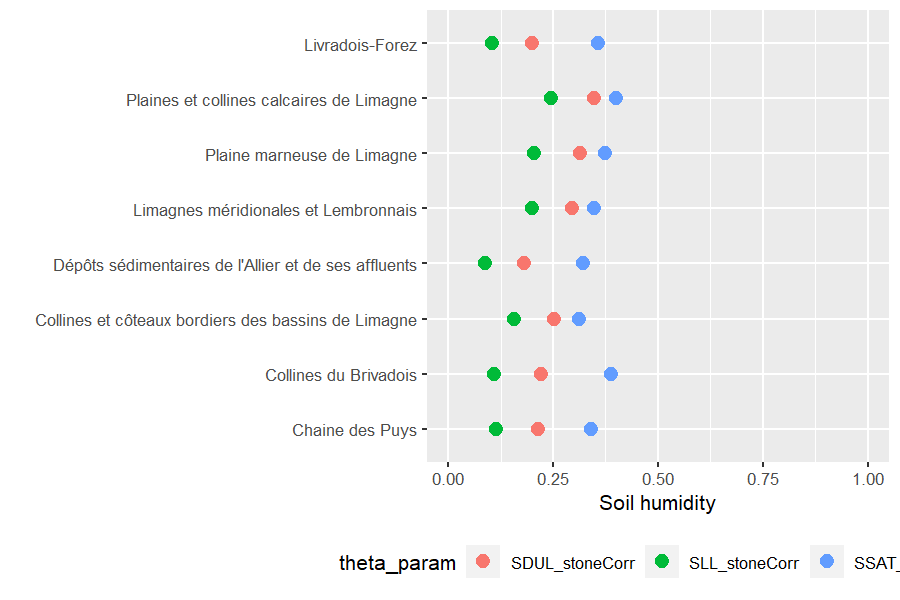

## 3.3. Visualisation globale de SSAT, SDUL, SLL, Kq et la profondeur des profils décrits pour chaque entité régionale

| regNat | z_0.5med | z_1st | z_med | z_9th | z_1.5med | SSAT | SDUL | SLL | Kq |
| --- | --- | --- | --- | --- | --- | --- | --- | --- | --- |
| Rebord Ouest des Limagnes | 30 | 25 | 55 | 80 | 85 | 0.340 | 0.214 | 0.114 | 0.952 |
| Collines du Brivadois | 30 | 55 | 55 | 90 | 85 | 0.390 | 0.221 | 0.110 | 0.982 |
| Collines et côteaux bordiers des bassins de Limagne | 40 | 60 | 75 | 100 | 115 | 0.312 | 0.251 | 0.157 | 0.760 |
| Dépôts sédimentaires et alluviaux de l’Allier et de ses affluents | 40 | 50 | 80 | 100 | 120 | 0.321 | 0.182 | 0.088 | 0.992 |
| Limagnes méridionales et Lembronnais | 40 | 40 | 80 | 110 | 120 | 0.348 | 0.295 | 0.201 | 0.546 |
| Livradois-Forez | 55 | 85 | 110 | 145 | 165 | 0.356 | 0.200 | 0.104 | 0.976 |
| Plaine marneuse de Limagne | 45 | 80 | 85 | 100 | 130 | 0.373 | 0.315 | 0.204 | 0.690 |
| Plaines et collines marno-calcaires de Limagne | 50 | 70 | 100 | 120 | 150 | 0.400 | 0.349 | 0.246 | 0.416 |